# Lesson 3

### Friends by Gender

Notes: there seem to be more males with fewer friends and more females with many friends

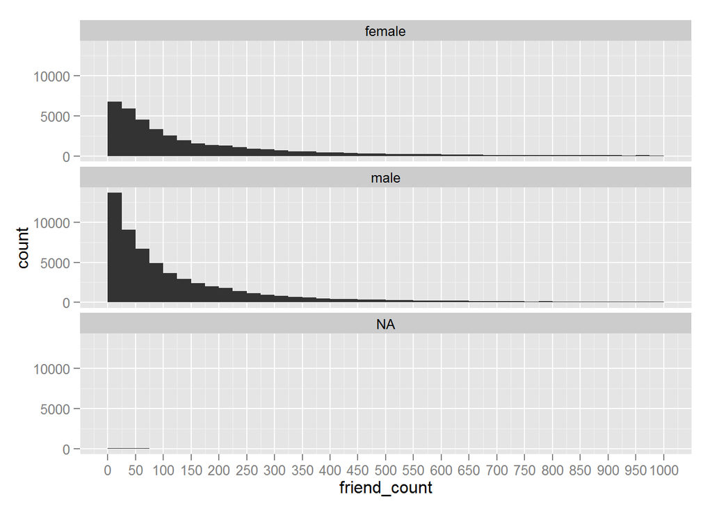

```r
qplot(x=friend_count, data=pf, binwidth=25)+
  scale_x_continuous(limits=c(0,1000),breaks=seq(0,1000,50))+
  facet_wrap(~gender,ncol=1)
```

### Omitting NA Values

Notes:

- `subset(data, !is.na(column))` removes observation where column is missing
- `na.omit(data)` removes all observation where any value is missing

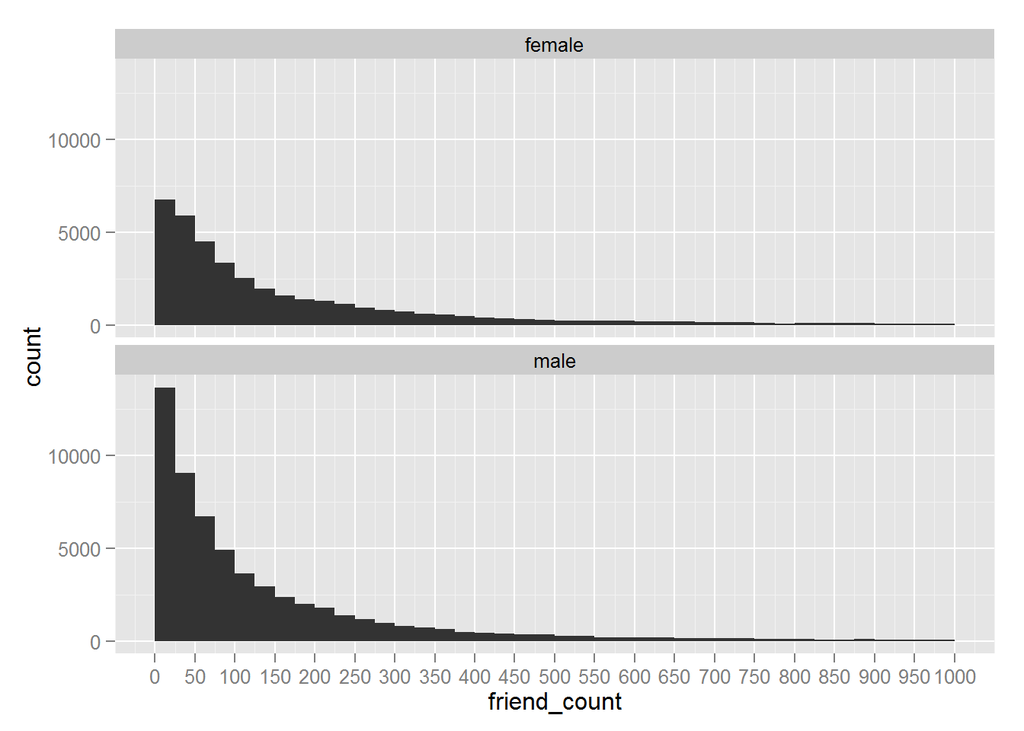

```r
qplot(x=friend_count, data=na.omit(pf), binwidth=25)+
  scale_x_continuous(limits=c(0,1000),breaks=seq(0,1000,50))+
  facet_wrap(~gender,ncol=1)
```

### Statistics ‘by’ Gender

Notes:

- `table(...)` tabulates instances of variable
- `by(var1, var2, summary)` shows stats for variable var1 depending on the instances of var2

```r
table(pf$gender)
```

```
##
## female   male
##  40254  58574
```

```r
by(pf$friend_count, pf$gender, summary)
```

```
## pf$gender: female
##    Min. 1st Qu.  Median    Mean 3rd Qu.    Max.
##       0      37      96     242     244    4923
## --------------------------------------------------------
## pf$gender: male
##    Min. 1st Qu.  Median    Mean 3rd Qu.    Max.
##       0      27      74     165     182    4917
```

#### Who on average has more friends: men or women?

Response: women

#### What’s the difference between the median friend count for women and men?

Response: 22

### Tenure

Notes:

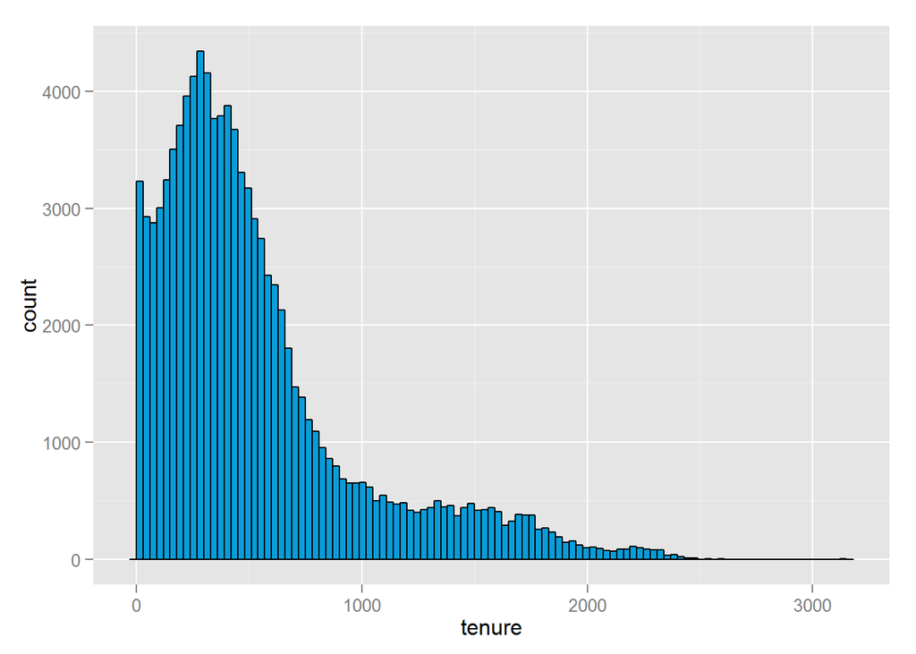

```r
qplot(x=tenure, data=pf, binwidth=30, color=I('black'), fill=I('#099dd9'))
```

#### How would you create a histogram of tenure by year?

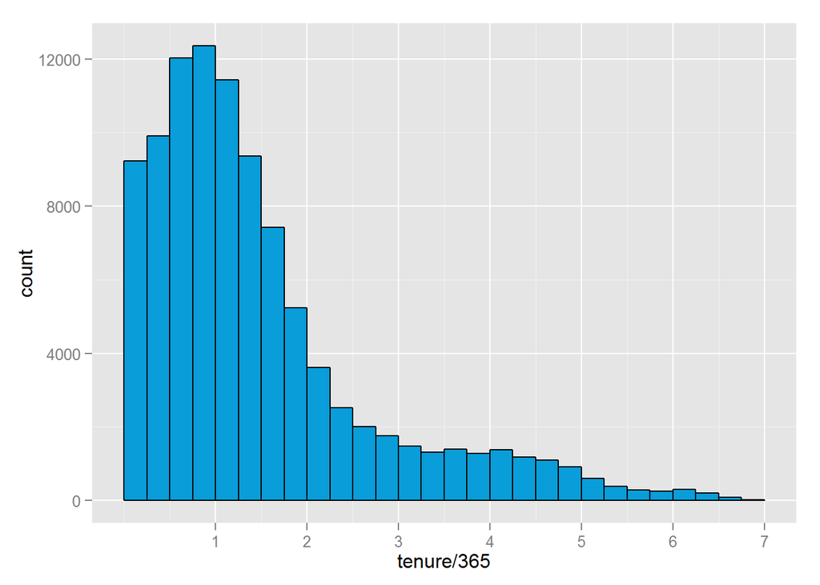

```r
qplot(x=tenure/365, data=pf, binwidth=.25, color=I('black'), fill=I('#099dd9')) +
  scale_x_continuous(breaks=seq(1,7,1), limits=c(0,7))
```

### Labeling Plots

Notes:

- labeling happens with `xlab` and `ylab`
- can work as comments in code also

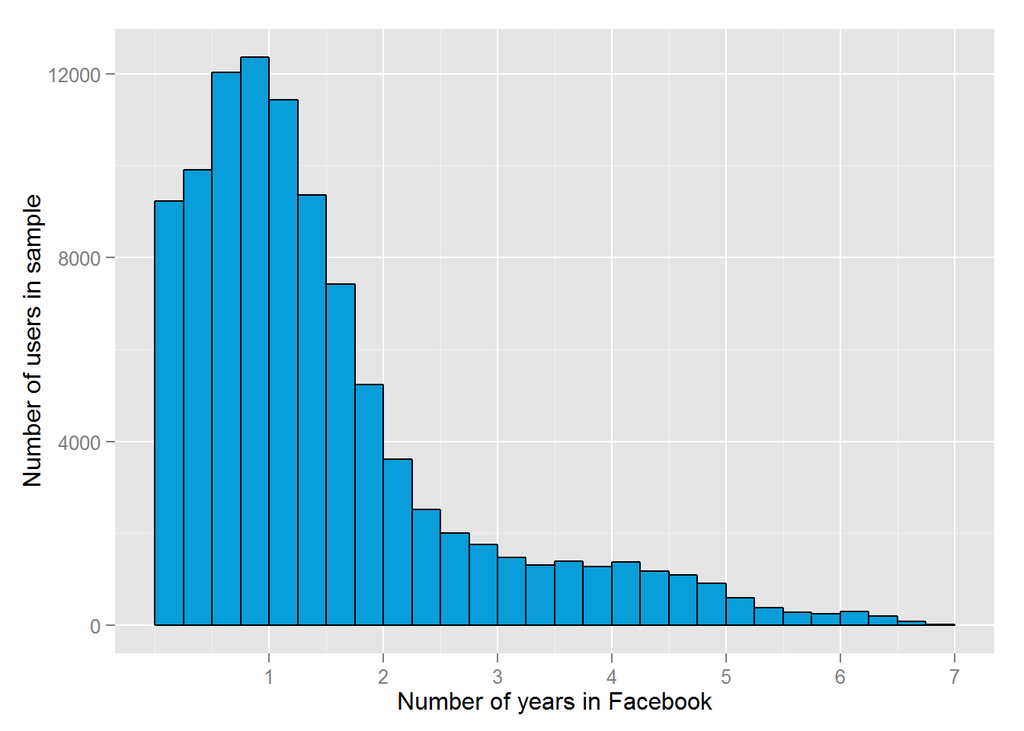

```r
qplot(x=tenure/365, data=pf, binwidth=.25, color=I('black'), fill=I('#099dd9'),
      xlab="Number of years in Facebook",
      ylab="Number of users in sample") +
  scale_x_continuous(breaks=seq(1,7,1), limits=c(0,7))
```

### User Ages

Notes: creating a plot with age distribution on facebook

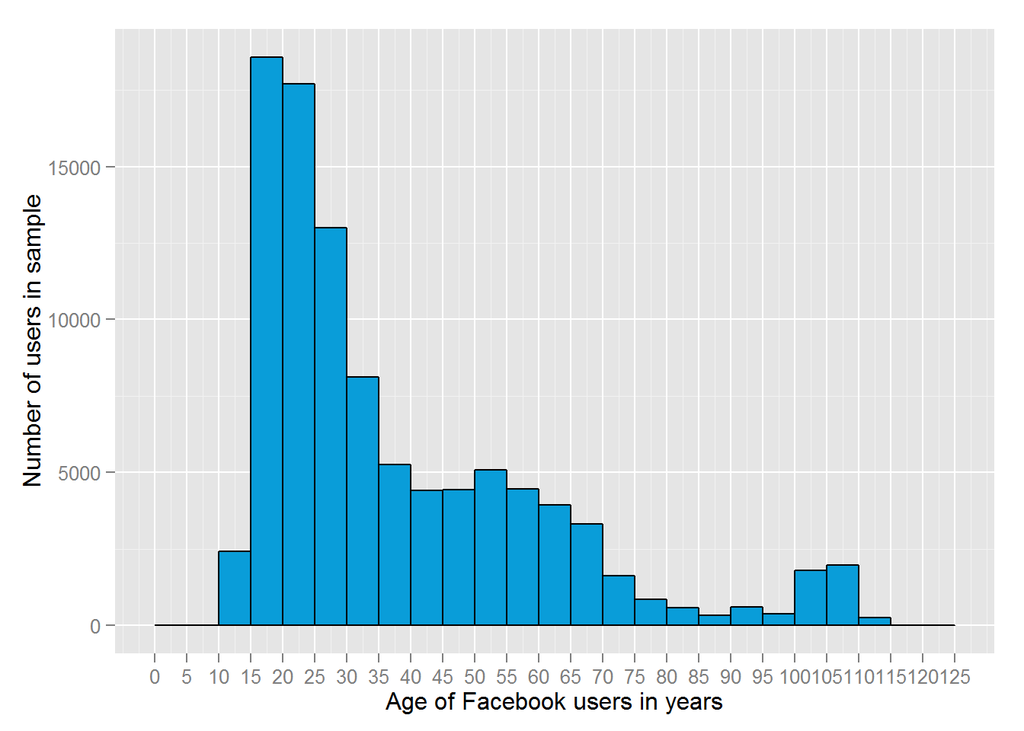

```r
qplot(x=age, data=pf, binwidth=5, color=I('black'), fill=I('#099dd9'),
      xlab="Age of Facebook users in years",
      ylab="Number of users in sample") +
  scale_x_continuous(breaks=seq(0,125,5), limits=c(0,125))
```

#### What do you notice?

Response:

- many users around the age of 20-25
- a big group of users older than 100 - fake?

### The Spread of Memes / Lada’s Money Bag Meme

Notes:

- memes = ideas that spread through social media
- some memes are time-contextual but do still re-occur

### Transforming Data

Notes:

- exponential / order of magnitude growth and decay much better by log scale (binary, natural or 10-based log)
- helps for making data more normally-distributed looking
- be careful if your data contains zeros (log of zero is undefined) - add 1 if possible
- “data is overdispersed”

### Add a Scaling Layer

Notes:

- library `gridExtra` lets you put many plots into one graph using `grid.arrange(...)`
- notice how log10 transformation looks much more like a normal distribution
- log transformed data works well for long-tailed variables!
- you can use `ggplot(aes(x=...), data=...) + geom_histogram()` corresponding to `qplot(x=..., data=...)`
- `ggplot(...)` can have additional layers like `scale_x_log10()` or `scale_x_sqrt()` - however, they do not re-label the axis

```r
# install.packages('gridExtra')
library(gridExtra)
```

```
## stat_bin: binwidth defaulted to range/30. Use 'binwidth = x' to adjust this.
## stat_bin: binwidth defaulted to range/30. Use 'binwidth = x' to adjust this.
## stat_bin: binwidth defaulted to range/30. Use 'binwidth = x' to adjust this.
```

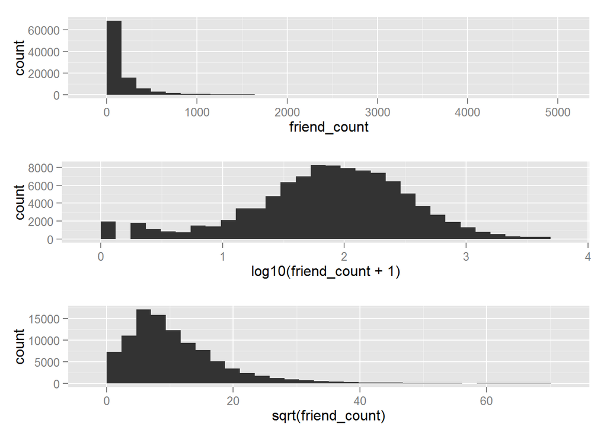

```r
p1 <- qplot(x=friend_count, data=pf)
p2 <- qplot(x=log10(friend_count+1), data=pf)
p3 <- qplot(x=sqrt(friend_count), data=pf)
grid.arrange(p1,p2,p3, ncol=1)
```

```
## stat_bin: binwidth defaulted to range/30. Use 'binwidth = x' to adjust this.
## stat_bin: binwidth defaulted to range/30. Use 'binwidth = x' to adjust this.
## stat_bin: binwidth defaulted to range/30. Use 'binwidth = x' to adjust this.
```

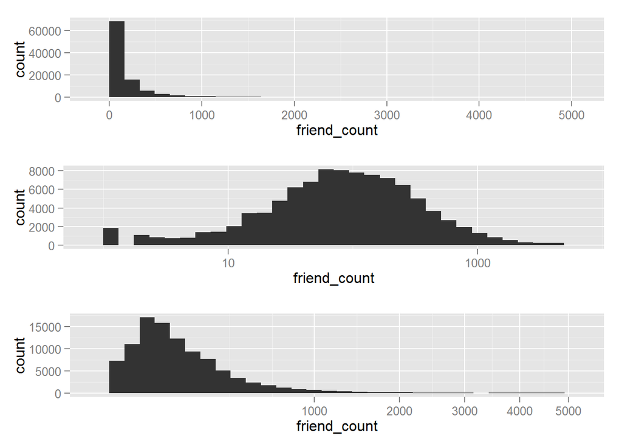

```r
# or
p1 <- ggplot(aes(x=friend_count), data=pf) + geom_histogram()
p2 <- p1 + scale_x_log10()
p3 <- p1 + scale_x_sqrt()
grid.arrange(p1,p2,p3, ncol=1)
```

### Frequency Polygons

Notes:

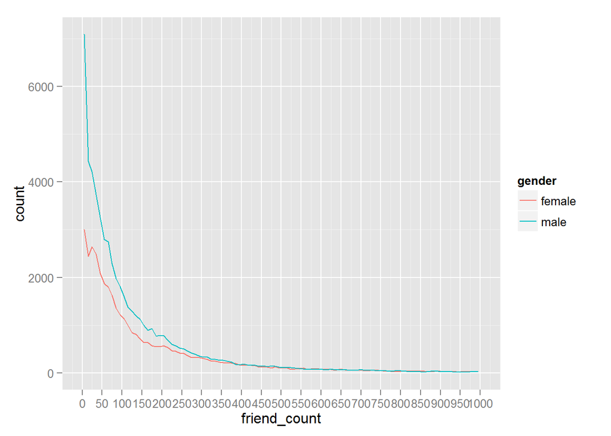

```r
qplot(x=friend_count,
      data=subset(pf, !is.na(gender)),
      binwidth=10, geom='freqpoly', color=gender) +
  scale_x_continuous(lim=c(0,1000), breaks=seq(0,1000,50))
```

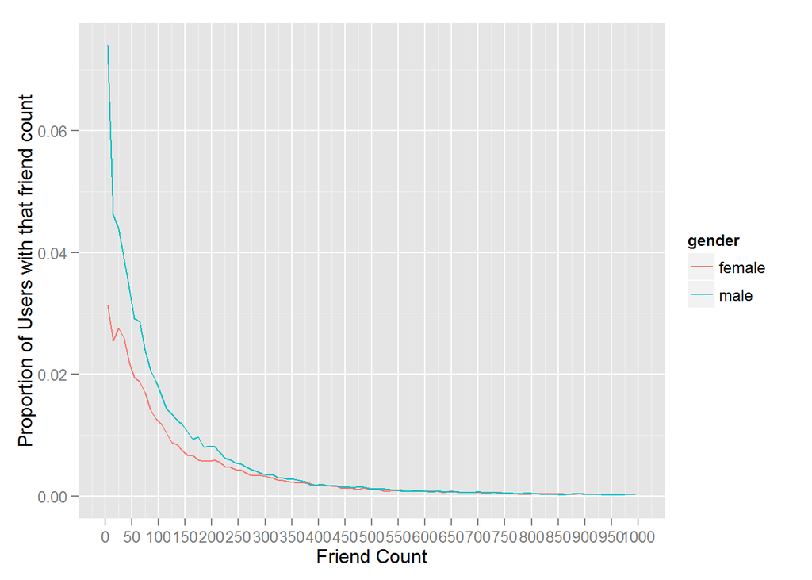

```r
qplot(x=friend_count, y = ..count../sum(..count..),
      data=subset(pf, !is.na(gender)),
      xlab='Friend Count',
      ylab='Proportion of Users with that friend count',
      binwidth=10, geom='freqpoly', color=gender) +
  scale_x_continuous(lim=c(0,1000), breaks=seq(0,1000,50))
```

### Likes on the Web

```
## stat_bin: binwidth defaulted to range/30. Use 'binwidth = x' to adjust this.
```

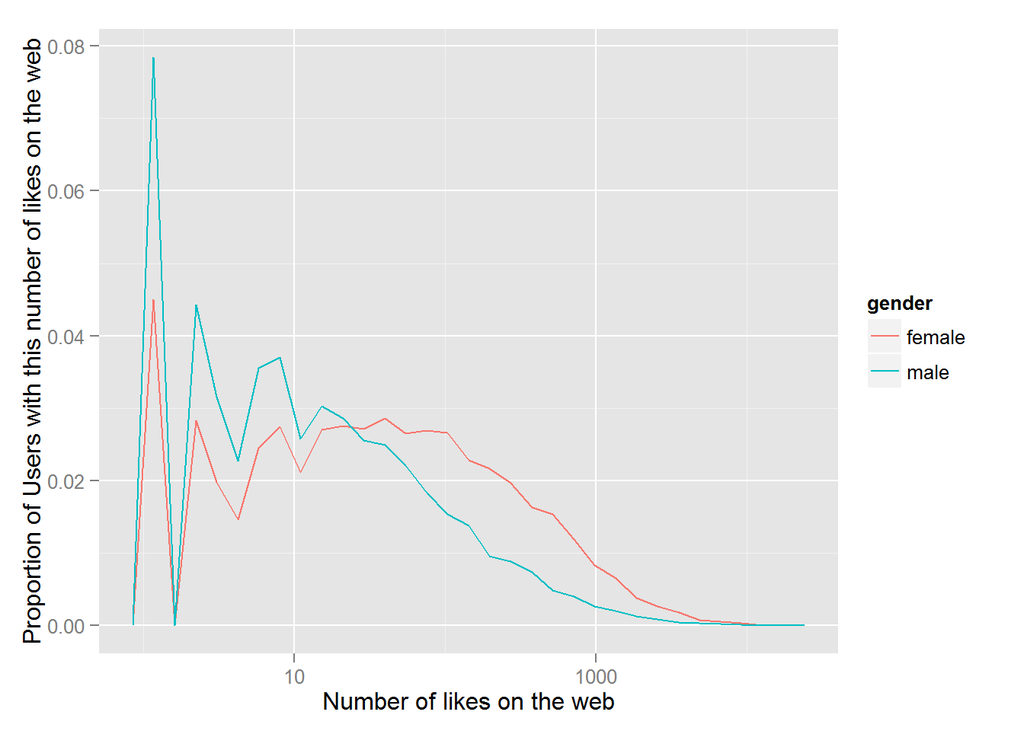

```r
qplot(x=www_likes, data=subset(pf, !is.na(gender)),
      y = ..count../sum(..count..),
      xlab='Number of likes on the web',
      ylab='Proportion of Users with this number of likes on the web',
      geom='freqpoly', color=gender) +
  scale_x_log10()
```

```r
by(pf$www_likes, pf$gender, sum)
```

```
## pf$gender: female
## [1] 3507665
## --------------------------------------------------------
## pf$gender: male
## [1] 1430175
```

### Are Likes more often used by males or females

Answer: females

Notes: use `by(..., sum)` to facet the data and get a sum

```r
by(pf$www_likes, pf$gender, sum)
```

```
## pf$gender: female
## [1] 3507665
## --------------------------------------------------------
## pf$gender: male
## [1] 1430175
```

### Box Plots

Notes: use `qplot(x=..., y=..., geom='boxplot')` to plot boxplots with x being the categorical variable and y the variable to examine

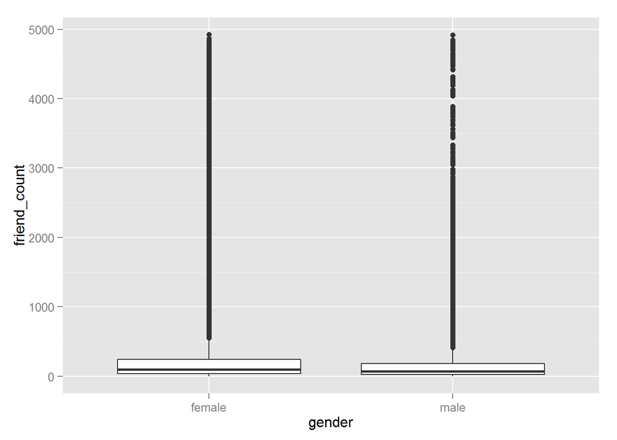

```r
qplot(y=friend_count, x=gender,
      data=subset(pf, !is.na(gender)),
      geom='boxplot')
```

#### Adjust the code to focus on users who have friend counts between 0 and 1000.

Notes:

- `qplot(...) + scale_y_continuous(limit=c(...))`
- `qplot(..., ylim=c(...))`
- `qplot(...) + coord_cartesian(ylim=c(...))` (better, does remove not remove data points)

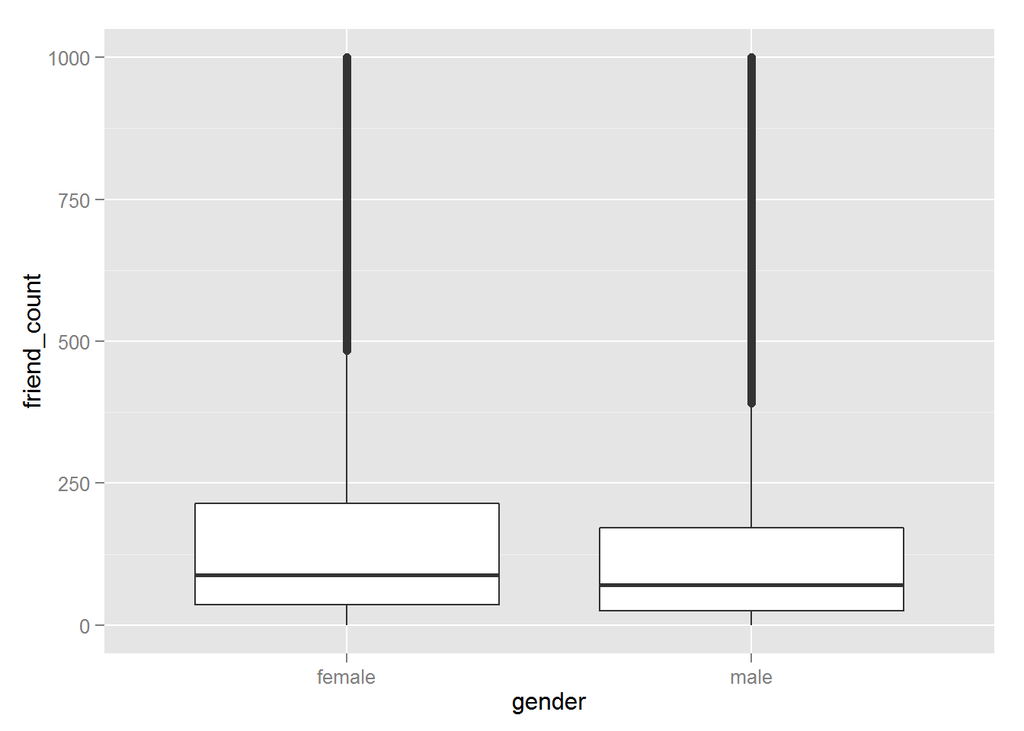

```r
qplot(y=friend_count, x=gender,
      data=subset(pf, !is.na(gender)),
      geom='boxplot',
      ylim=c(0,1000))
```

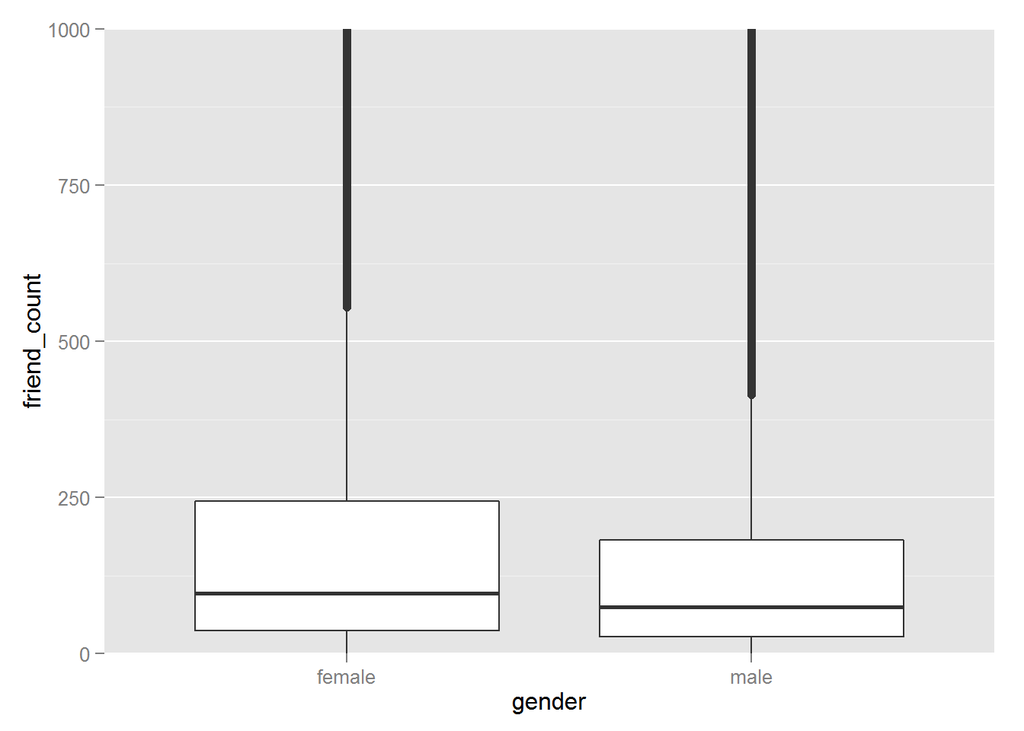

```r
# better:
qplot(y=friend_count, x=gender,
      data=subset(pf, !is.na(gender)),
      geom='boxplot') +
  coord_cartesian(ylim=c(0,1000))
```

### Box Plots, Quartiles, and Friendships

Notes:

- black line: median
- box represents middle 50% of the data

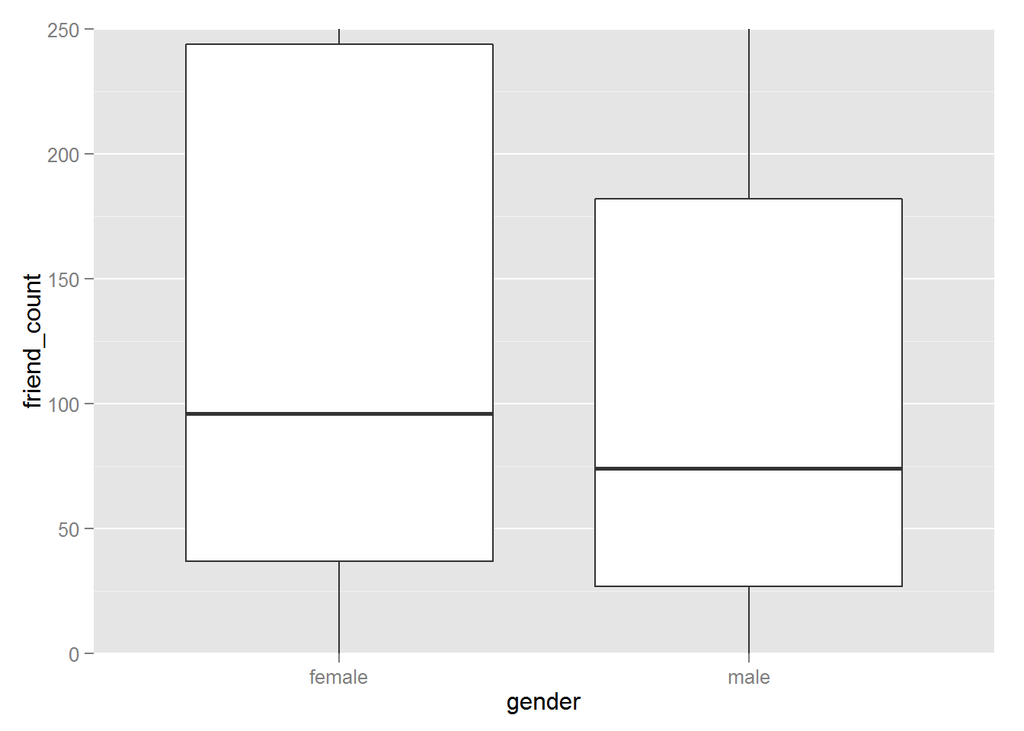

```r
qplot(x=gender, y=friend_count, data=subset(pf, !is.na(gender)), geom='boxplot') +
  coord_cartesian(ylim=c(0,250))
```

#### On average, who initiated more friendships in our sample: men or women?

Response: female

#### Write about some ways that you can verify your answer:

Response: use the “by” function to facet friend_count by gender and get the mean: `by(pf$friend_count, pf$gender, mean)`

```r
by(pf$friend_count, pf$gender, mean)
```

```
## pf$gender: female
## [1] 241.9699
## --------------------------------------------------------
## pf$gender: male
## [1] 165.0355
```

### Getting Logical

Notes:

```r
summary(pf$mobile_likes)
```

```
##    Min. 1st Qu.  Median    Mean 3rd Qu.    Max.
##     0.0     0.0     4.0   106.1    46.0 25110.0
```

```r
summary(pf$mobile_likes>0)
```

```
##    Mode   FALSE    TRUE    NA's
## logical   35056   63947       0
```

```r
pf$mobile_check_in <- NA
pf$mobile_check_in <- ifelse(pf$mobile_likes>0, 1, 0)
pf_mobile_check_in <- factor(pf$mobile_check_in)
summary(pf$mobile_check_in)
```

```
##    Min. 1st Qu.  Median    Mean 3rd Qu.    Max.
##  0.0000  0.0000  1.0000  0.6459  1.0000  1.0000
```

```r
sum(pf$mobile_check_in==1)/length(pf$mobile_check_in)
```

```
## [1] 0.6459097
```

Response:

### Analyzing One Variable

Reflection:

- what variables exist? do they have outliers or missing data?
- analyze the data using boxplots, histograms and frequency polygons
- use different scaling (log or sqrt scale) for long-tailed data
- facet data accordingly (facet wraps and multiple layers)
- analyze interquartile ranges, mean, median
- create proxy variables (with logical expressions)
- style up diagrams

Click **KnitHTML** to see all of your hard work and to have an html page of this lesson, your answers, and your notes!